Skip to content

Akif MustafaBiostatistician.

# An Introduction to Restricted Mean Survival Time (RMST)

Author

Akif Mustafa ✉

Published

June 1, 2026

## 1 Introduction

The **Cox proportional hazards (CPH) model** is the go-to model for survival analysis. It is popular for good reasons:

- It is semi-parametric — no distributional assumption needed.
- It handles multiple predictor variables.
- It gives an easy-to-interpret summary: the **hazard ratio (HR)**.
- It handles censoring naturally.

But it makes one strong assumption: **proportional hazards (PH)**.

This means the hazard of the event in two groups must always remain proportional throughout the study period. Everything works well when this holds.

**What if it does not hold?**

When hazards are not proportional — for example, when survival curves cross, when there is a delayed treatment effect, or when the benefit diminishes over time — a single HR becomes misleading. It no longer summarizes the treatment effect well.

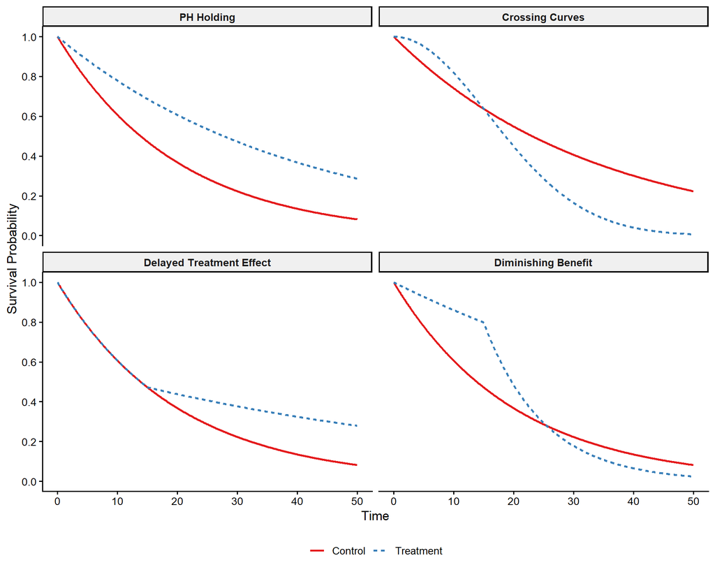

Potential hazard scenarious

In these situations, there are several analytical alternatives to the standard Cox model:

- Piecewise Cox model
- Cox model with time-varying coefficients
- Royston-Parmar parametric model
- Accelerated failure time (AFT) model
- Cure models

**Restricted Mean Survival Time (RMST)** is one such alternative. It is practical, interpretable, and widely used when the proportional hazards assumption is violated.

## 2 What is RMST?

The **Restricted Mean Survival Time (RMST)** up to a time point $\tau$ is:

- The **average time** a person survives from time 0 to time $\tau$.
- Equivalently, the **area under the survival curve** $S(t)$ from 0 to $\tau$.

Mathematically:

$$\text{RMST}(\tau) = E[\min(T, \tau)] = \int_0^{\tau} S(t)\, dt$$

Two key points:

- **“Restricted”** means we only look up to a pre-specified horizon $\tau$ (e.g., 5 years), not to infinity.
- It is a **non-parametric** summary of the whole survival curve up to $\tau$. No proportional hazards assumption. No specific model required.

### 2.1 Visualizing RMST: Area Under the Curve

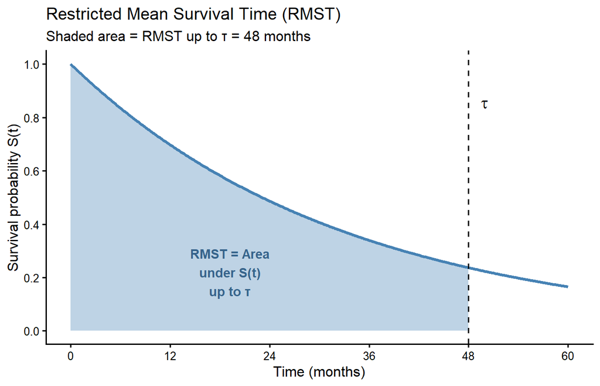

RMST is the area under the survival curve S(t) from time 0 to τ

```r
set.seed(1)
tau <- 48

t_seq <- seq(0, 60, by = 0.1)
s_t   <- exp(-0.03 * t_seq)

df_line <- data.frame(time = t_seq, surv = s_t)
df_shade <- data.frame(
  time = c(0, t_seq[t_seq <= tau], tau),
  surv = c(0, s_t[t_seq <= tau],  0)
)

ggplot() +
  geom_polygon(data = df_shade, aes(time, surv),
               fill = "steelblue", alpha = 0.35) +
  geom_line(data = df_line, aes(time, surv),
            color = "steelblue", linewidth = 1.2) +
  geom_vline(xintercept = tau, linetype = "dashed", color = "black") +
  annotate("text", x = tau + 1.5, y = 0.85, label = expression(tau),
           size = 5, hjust = 0) +
  annotate("text", x = tau / 2.5, y = 0.22,
           label = "RMST = Area\nunder S(t)\nup to τ",
           size = 3.8, color = "steelblue4", fontface = "bold") +
  labs(
    title    = "Restricted Mean Survival Time (RMST)",
    subtitle = paste0("Shaded area = RMST up to τ = ", tau, " months"),
    x        = "Time (months)",
    y        = "Survival probability S(t)"
  ) +
  scale_x_continuous(breaks = seq(0, 60, 12)) +
  scale_y_continuous(limits = c(0, 1), breaks = seq(0, 1, 0.2)) +
  theme_classic(base_size = 12)
```

### 2.2 RMST for Two Groups

For two groups (e.g., treatment vs. control), the **difference in RMST** is the area *between* the two survival curves from 0 to $\tau$.

It tells you: **on average, how much extra survival time does the treatment provide up to time** $\tau$?

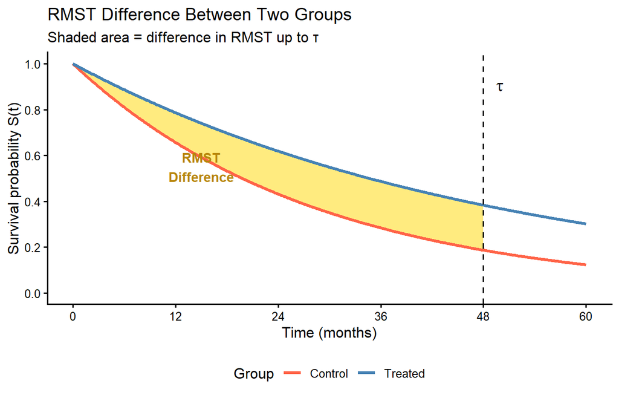

RMST difference = shaded area between the two survival curves up to τ

```r
set.seed(2)
tau <- 48

t_seq  <- seq(0, 60, by = 0.1)
s_trt  <- exp(-0.020 * t_seq)
s_ctrl <- exp(-0.035 * t_seq)

df_two <- data.frame(
  time    = t_seq,
  Treated = s_trt,
  Control = s_ctrl
) |> tidyr::pivot_longer(-time, names_to = "Group", values_to = "Survival")

df_between <- data.frame(
  time  = c(t_seq[t_seq <= tau], rev(t_seq[t_seq <= tau])),
  surv  = c(s_trt[t_seq <= tau],  rev(s_ctrl[t_seq <= tau]))
)

ggplot() +
  geom_polygon(data = df_between, aes(time, surv),
               fill = "gold", alpha = 0.5) +
  geom_line(data = df_two, aes(time, Survival, color = Group),
            linewidth = 1.2) +
  geom_vline(xintercept = tau, linetype = "dashed", color = "black") +
  annotate("text", x = tau + 1.5, y = 0.9, label = expression(tau),
           size = 5, hjust = 0) +
  annotate("text", x = 15, y = 0.55,
           label = "RMST\nDifference",
           size = 3.8, color = "darkgoldenrod", fontface = "bold") +
  scale_color_manual(values = c("Control" = "tomato", "Treated" = "steelblue")) +
  labs(
    title    = "RMST Difference Between Two Groups",
    subtitle = "Shaded area = difference in RMST up to τ",
    x        = "Time (months)",
    y        = "Survival probability S(t)"
  ) +
  scale_x_continuous(breaks = seq(0, 60, 12)) +
  scale_y_continuous(limits = c(0, 1), breaks = seq(0, 1, 0.2)) +
  theme_classic(base_size = 12) +
  theme(legend.position = "bottom")
```

## 3 Why RMST? Limitations of the Cox Model

The Cox model gives hazard ratios. HRs are useful, but they have real limitations.

### 3.1 PH Assumption

The Cox model requires **proportional hazards**. If hazards are not proportional (crossing curves, delayed effects, diminishing benefits), a single HR is misleading.

> In immuno-oncology, for example, survival curves often separate late or cross altogether. The PH assumption frequently fails here.

### 3.2 HR is Relative, Not Absolute

HR = 0.6 means a 40% lower hazard. But what does that mean in **months of life gained**? That depends on the baseline hazard — a detail HR does not convey.

Clinicians and patients often more interested in:

> *“How much extra time do I get, on average?”*

than about a hazard ratio.

### 3.3 HR is Model-Based

The Cox HR is a model-based summary. If the model is wrong — due to non-proportional hazards or misspecification — the HR can be biased and difficult to interpret.

### 3.4 How RMST Addresses These Limitations

| Issue | Cox HR | RMST |
| --- | --- | --- |
| Requires PH assumption | ✅ Yes | ❌ No |
| Absolute effect size | ❌ No | ✅ Yes (time gained) |
| Model-free | ❌ No | ✅ Yes (from KM curve) |
| Easy clinical communication | ⚠️ Moderate | ✅ High |

> **RMST is not a replacement for the Cox model in all settings.** It is a complement and an alternative — especially when PH fails or an absolute effect size matters more.

## 4 When to Use RMST?

### 4.1 Use RMST When:

**1. Non-proportional hazards (NPH) are present**

- Crossing survival curves
- Delayed treatment effect (early overlap, later separation)
- Diminishing benefit (early benefit that later fades)

**2. An absolute effect is more meaningful than a relative one**

- *“Patients in the active arm survive on average 3 months longer over 5 years.”*
- Health economics: quantifying life-years gained within a fixed horizon.

**3. You want a model-free summary**

- No reliance on a correctly specified Cox model.
- Simple, robust comparison of two survival curves up to $\tau$.

**4. As a supplement to HRs and log-rank tests**

- Even when PH holds, RMST can be reported alongside the HR to provide an absolute effect estimate.
- Many recent clinical trials in oncology report both HR and RMST difference.

### 4.2 You Probably Do Not Need RMST When:

- PH holds well, **and**
- HR is sufficient for your scientific or clinical question, **and**
- There is no strong demand for an absolute “time gained” interpretation.

## 5 Estimation

### 5.1 Single Group

The steps are straightforward:

1. Estimate the survival curve $S(t)$ using the **Kaplan–Meier** estimator.
2. Choose a clinically relevant truncation time $\tau$ (e.g., 5 years). Pre-specify this before the analysis.
3. Compute the area under the KM curve from 0 to $\tau$ using the **trapezoidal rule** (sum of rectangles under the step function).
4. Estimate the **standard error** using a Greenwood-type formula.
5. Construct **confidence intervals** using asymptotic normality (for large samples).

### 5.2 Two-Group Comparison

Let $S_1(t)$ and $S_0(t)$ be the KM curves in the treatment and control groups.

$$\text{RMST}_1(\tau) = \int_0^{\tau} S_1(t)\, dt \qquad
\text{RMST}_0(\tau) = \int_0^{\tau} S_0(t)\, dt$$

Three key summary measures:

**1. Difference in RMST (most common)**

$$\Delta(\tau) = \text{RMST}_1(\tau) - \text{RMST}_0(\tau)
= \int_0^{\tau} [S_1(t) - S_0(t)]\, dt$$

*Interpretation*: On average, how many extra months does treatment provide by time $\tau$?

**2. Ratio of RMST**

$$\frac{\text{RMST}_1(\tau)}{\text{RMST}_0(\tau)}$$

*Interpretation*: Relative increase in average survival time up to $\tau$.

**3. Ratio of Restricted Mean Time Lost (RMTL)**

$$\text{RMTL}(\tau) = \tau - \text{RMST}(\tau)$$

This is the average time **lost** due to the event before $\tau$.

$$\text{RMTL ratio} = \frac{\text{RMTL}_1(\tau)}{\text{RMTL}_0(\tau)}$$

*Interpretation*: Useful when the focus is on time lost rather than time lived.

**Inference** (difference and ratio):

- Based on asymptotic normality with Greenwood-based variance estimates.
- Provides standard errors, confidence intervals, and p-values.

## 6 Choosing $\tau$

The choice of $\tau$ matters. Some guidance:

- $\tau$ should be **clinically chosen and pre-specified** before the analysis (e.g., 5-year RMST in a cancer trial).
- It must fall **within the observed follow-up** where enough events have occurred and the KM estimate is reliable (i.e., do not extrapolate beyond the last event time).
- A common practical rule: set $\tau$ at or before the **minimum of the two groups’ last event times**, or at a **clinically meaningful landmark** such as 1, 2, or 5 years.
- Some methods choose $\tau$ adaptively, but a **fixed, pre-specified** $\tau$ is preferred for transparency and interpretability.

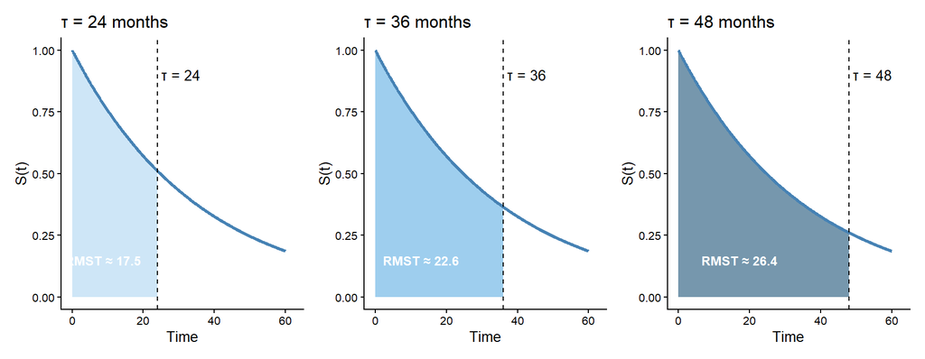

Effect of τ choice on RMST estimation. The shaded areas show RMST for three different values of τ.

## 7 Example in R

Here we simulate a delayed treatment effect:

- Before 12 months: treatment and control have similar hazard.
- After 12 months: treatment hazard becomes lower.

This violates proportional hazards.

### 7.1 Simulate Data

```r
library(survival)
library(survRM2)
library(ggplot2)
library(dplyr)
library(tibble)
library(knitr)
library(kableExtra)

set.seed(999)

n <- 600
arm <- rbinom(n, 1, 0.5)  # 0 = control, 1 = treatment

# Control: constant hazard throughout
t_control <- rexp(n, rate = 0.05)

# Treatment: same hazard before 12 months, lower hazard after 12 months
t1 <- rexp(n, rate = 0.05)
t_treat <- ifelse(t1 < 12, t1, 12 + rexp(n, rate = 0.02))

time_event <- ifelse(arm == 0, t_control, t_treat)

# Administrative censoring at 36 months
time   <- pmin(time_event, 36)
status <- as.integer(time_event <= 36)

dat <- tibble(
  time   = time,
  status = status,
  arm    = factor(arm, levels = c(0, 1), labels = c("Control", "Treatment"))
)

# Summary table
dat |>
  group_by(arm) |>
  summarise(
    N            = n(),
    Events       = sum(status),
    Censored     = N - Events,
    Max_followup = round(max(time), 1),
    .groups      = "drop"
  ) |>
  kable(
    caption   = "Summary of simulated dataset",
    col.names = c("Group", "N", "Events", "Censored", "Max Follow-up (months)")
  ) |>
  kable_styling(bootstrap_options = c("striped", "hover", "condensed"),
                full_width = FALSE)
```

Summary of simulated dataset

| Group | N | Events | Censored | Max Follow-up (months) |
| --- | --- | --- | --- | --- |
| Control | 302 | 248 | 54 | 36 |
| Treatment | 298 | 208 | 90 | 36 |

### 7.2 Kaplan–Meier Curves

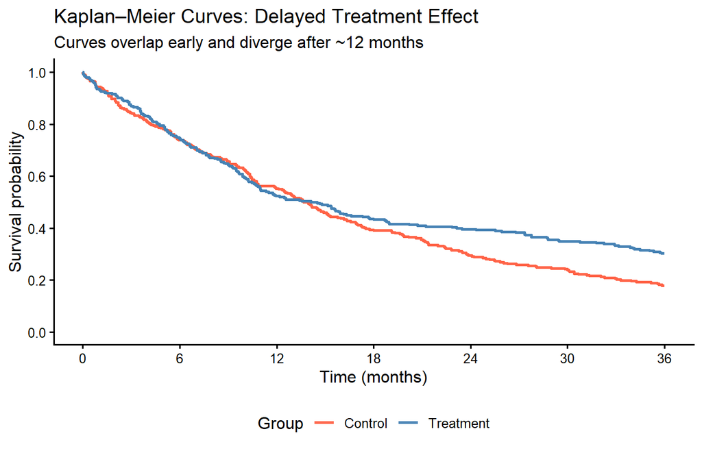

Kaplan–Meier curves for simulated delayed treatment effect data

```r
fit_km <- survfit(Surv(time, status) ~ arm, data = dat)

# Extract KM step data for ggplot
km_df <- data.frame(
  time   = fit_km$time,
  surv   = fit_km$surv,
  strata = rep(names(fit_km$strata), fit_km$strata)
) |>
  mutate(arm = sub("arm=", "", strata))

# Add time = 0 rows for each group
time0 <- data.frame(
  time   = 0,
  surv   = 1,
  strata = NA,
  arm    = c("Control", "Treatment")
)

km_plot_df <- bind_rows(time0, km_df) |>
  arrange(arm, time)

ggplot(km_plot_df, aes(x = time, y = surv, color = arm)) +
  geom_step(linewidth = 1) +
  scale_color_manual(
    name   = "Group",
    values = c("Control" = "tomato", "Treatment" = "steelblue")
  ) +
  scale_x_continuous(limits = c(0, 36), breaks = seq(0, 36, 6)) +
  scale_y_continuous(limits = c(0, 1),  breaks = seq(0, 1, 0.2)) +
  labs(
    title    = "Kaplan–Meier Curves: Delayed Treatment Effect",
    subtitle = "Curves overlap early and diverge after ~12 months",
    x        = "Time (months)",
    y        = "Survival probability"
  ) +
  theme_classic(base_size = 12) +
  theme(legend.position = "bottom")
```

The curves initially overlap, reflecting similar early hazards. After 12 months they diverge as the treatment arm benefits from a lower hazard. This pattern suggests a violation of the proportional hazards assumption.

### 7.3 Check the Proportional Hazards Assumption

#### 7.3.1 First, lets fit the cox PH model

```r
cox_fit <- coxph(Surv(time, status) ~ arm, data = dat)
summary(cox_fit)
```

```
Call:
coxph(formula = Surv(time, status) ~ arm, data = dat)

  n= 600, number of events= 456

                 coef exp(coef) se(coef)      z Pr(>|z|)
armTreatment -0.23982   0.78677  0.09429 -2.543    0.011 *
---
Signif. codes:  0 '***' 0.001 '**' 0.01 '*' 0.05 '.' 0.1 ' ' 1

             exp(coef) exp(-coef) lower .95 upper .95
armTreatment    0.7868      1.271     0.654    0.9465

Concordance= 0.518  (se = 0.013 )
Likelihood ratio test= 6.5  on 1 df,   p=0.01
Wald test            = 6.47  on 1 df,   p=0.01
Score (logrank) test = 6.5  on 1 df,   p=0.01
```

#### 7.3.2 Now, check the PH assumption using schoenfeld test

```r
zph <- cox.zph(cox_fit)

# Print test result as a neat table
as.data.frame(zph$table) |>
  kable(
    caption = "Schoenfeld residuals test for proportional hazards",
    digits  = 4
  ) |>
  kable_styling(bootstrap_options = c("striped", "hover", "condensed"),
                full_width = FALSE)
```

Schoenfeld residuals test for proportional hazards

|  | chisq | df | p |
| --- | --- | --- | --- |
| arm | 8.4937 | 1 | 0.0036 |
| GLOBAL | 8.4937 | 1 | 0.0036 |

> A p-value below 0.05 on the Schoenfeld test indicates a violation of the PH assumption.

#### 7.3.3 Plot the Schoenfeld residuals for visual inspection

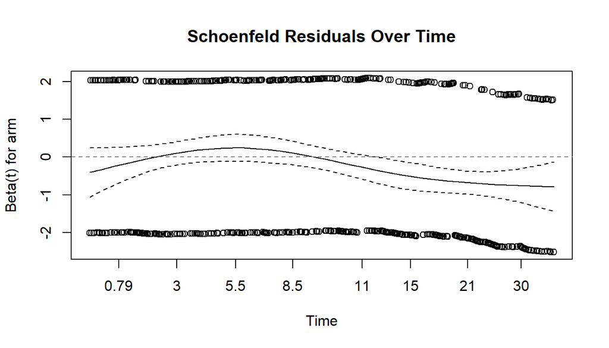

Scaled Schoenfeld residuals. A flat line suggests PH holds; a trend suggests violation.

```r
plot(zph, main = "Schoenfeld Residuals Over Time")
abline(h = 0, lty = 2, col = "grey50")
```

> A non-linear trend in the residuals plot confirms this. PH is violated here — making RMST a better choice.

### 7.4 Compute RMST

We use the `survRM2` package and set $\tau = 36$ months.

```r
tau_val <- 36

rm <- rmst2(
  time   = dat$time,
  status = dat$status,
  arm    = as.integer(dat$arm == "Treatment"),  # 1 = treatment, 0 = control
  tau    = tau_val
)

rm
```

```
The truncation time: tau = 36  was specified.

Restricted Mean Survival Time (RMST) by arm
               Est.    se lower .95 upper .95
RMST (arm=1) 18.613 0.804    17.038    20.189
RMST (arm=0) 16.722 0.716    15.319    18.125


Restricted Mean Time Lost (RMTL) by arm
               Est.    se lower .95 upper .95
RMTL (arm=1) 17.387 0.804    15.811    18.962
RMTL (arm=0) 19.278 0.716    17.875    20.681


Between-group contrast
                      Est. lower .95 upper .95     p
RMST (arm=1)-(arm=0) 1.891    -0.218     4.001 0.079
RMST (arm=1)/(arm=0) 1.113     0.988     1.254 0.078
RMTL (arm=1)/(arm=0) 0.902     0.803     1.013 0.082
```

#### 7.4.1 Results Tables

```r
arm1_vec <- unlist(rm$RMST.arm1)
arm0_vec <- unlist(rm$RMST.arm0)

rmst_trt_est  <- as.numeric(arm1_vec[1])
rmst_trt_lo   <- as.numeric(arm1_vec[2])
rmst_trt_hi   <- as.numeric(arm1_vec[3])

rmst_ctrl_est <- as.numeric(arm0_vec[1])
rmst_ctrl_lo  <- as.numeric(arm0_vec[2])
rmst_ctrl_hi  <- as.numeric(arm0_vec[3])

rmst_summary <- data.frame(
  Group = c("Treatment", "Control"),
  RMST  = c(rmst_trt_est,  rmst_ctrl_est),
  Lower = c(rmst_trt_lo,   rmst_ctrl_lo),
  Upper = c(rmst_trt_hi,   rmst_ctrl_hi)
)

rmst_summary |>
  kable(
    caption   = paste0("RMST estimates up to τ = ", tau_val, " months"),
    col.names = c("Group", "RMST (months)", "95% CI Lower", "95% CI Upper"),
    digits    = 2
  ) |>
  kable_styling(
    bootstrap_options = c("striped", "hover", "condensed"),
    full_width = FALSE
  )
```

RMST estimates up to τ = 36 months

[output not shown]

#### 7.4.2 Contrast Table

```r
contrast_df <- as.data.frame(rm$unadjusted.result)
contrast_df$Measure <- c(
  "RMST Difference (Treatment - Control)",
  "RMST Ratio (Treatment / Control)",
  "RMTL Ratio (Treatment / Control)"
)
contrast_df <- contrast_df[, c("Measure", "Est.", "lower .95", "upper .95", "p")]

contrast_df |>
  kable(
    caption   = "RMST contrast measures",
    col.names = c("Measure", "Estimate", "95% CI Lower", "95% CI Upper", "P-value"),
    digits    = c(0, 2, 2, 2, 4)
  ) |>
  kable_styling(bootstrap_options = c("striped", "hover", "condensed"),
                full_width = FALSE)
```

RMST contrast measures

|  | Measure | Estimate | 95% CI Lower | 95% CI Upper | P-value |
| --- | --- | --- | --- | --- | --- |
| RMST (arm=1)-(arm=0) | RMST Difference (Treatment - Control) | 1.89 | -0.22 | 4.00 | 0.0789 |
| RMST (arm=1)/(arm=0) | RMST Ratio (Treatment / Control) | 1.11 | 0.99 | 1.25 | 0.0780 |
| RMTL (arm=1)/(arm=0) | RMTL Ratio (Treatment / Control) | 0.90 | 0.80 | 1.01 | 0.0816 |

### 7.5 Visualize RMST

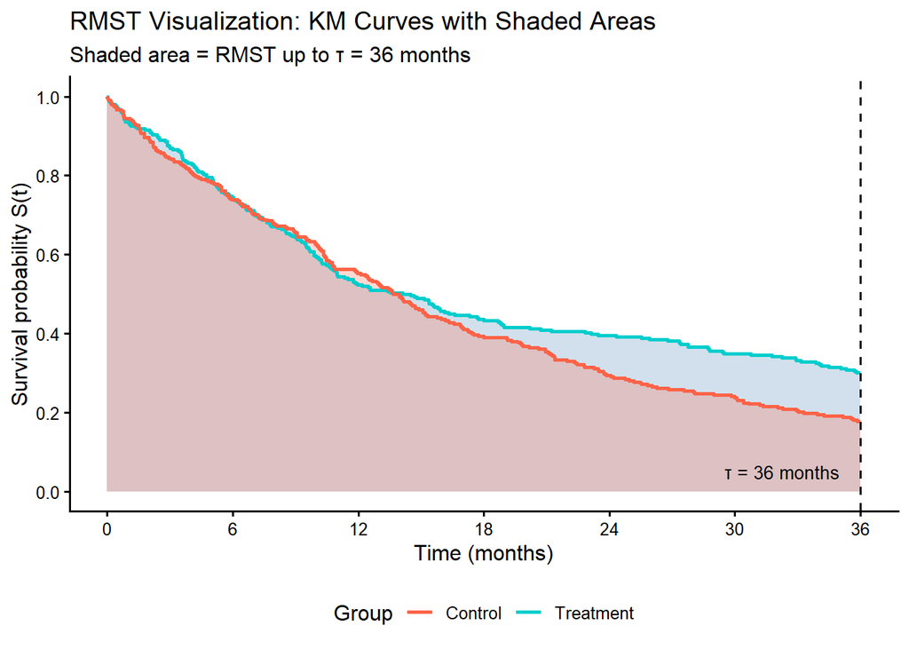

KM curves with shaded RMST areas up to τ = 36 months

```r
# Fit separate KM curves for each arm
km_trt  <- survfit(Surv(time, status) ~ 1, data = filter(dat, arm == "Treatment"))
km_ctrl <- survfit(Surv(time, status) ~ 1, data = filter(dat, arm == "Control"))

# Helper: convert survfit object to a step-function data frame
km_to_df <- function(km_obj, group_label) {
  data.frame(
    time  = c(0, km_obj$time),
    surv  = c(1, km_obj$surv),
    group = group_label
  )
}

df_trt  <- km_to_df(km_trt,  "Treatment")
df_ctrl <- km_to_df(km_ctrl, "Control")

# Helper: build a closed polygon for shading up to tau
make_shade <- function(df, tau_limit) {
  # Keep only time points up to tau
  df_trunc <- df[df$time <= tau_limit, ]
  # Add a closing point at tau with the last survival value
  df_trunc <- rbind(df_trunc,
                    data.frame(time  = tau_limit,
                               surv  = tail(df_trunc$surv, 1),
                               group = df_trunc$group[1]))
  # Close the polygon back to zero
  data.frame(
    time  = c(0,             df_trunc$time, tau_limit, 0),
    surv  = c(0,             df_trunc$surv, 0,         0),
    group = df_trunc$group[1]
  )
}

shade_trt  <- make_shade(df_trt,  tau_val)
shade_ctrl <- make_shade(df_ctrl, tau_val)

ggplot() +
  # Shaded RMST areas
  geom_polygon(data = shade_trt,
               aes(time, surv),
               fill = "steelblue", alpha = 0.25) +
  geom_polygon(data = shade_ctrl,
               aes(time, surv),
               fill = "tomato", alpha = 0.25) +
  # KM step curves
  geom_step(data = df_trt,
            aes(time, surv, color = "Treatment"),
            linewidth = 1) +
  geom_step(data = df_ctrl,
            aes(time, surv, color = "Control"),
            linewidth = 1) +
  # Tau line
  geom_vline(xintercept = tau_val, linetype = "dashed", color = "black") +
  annotate("text",
           x = tau_val - 1, y = 0.05,
           label = paste0("\u03c4 = ", tau_val, " months"),
           hjust = 1, size = 3.5) +
  scale_color_manual(
    name   = "Group",
    values = c("Treatment" = "cyan3", "Control" = "tomato")
  ) +
  scale_x_continuous(limits = c(0, 36), breaks = seq(0, 36, 6)) +
  scale_y_continuous(limits = c(0, 1),  breaks = seq(0, 1, 0.2)) +
  labs(
    title    = "RMST Visualization: KM Curves with Shaded Areas",
    subtitle = paste0("Shaded area = RMST up to \u03c4 = ", tau_val, " months"),
    x        = "Time (months)",
    y        = "Survival probability S(t)"
  ) +
  theme_classic(base_size = 12) +
  theme(legend.position = "bottom")
```

### 7.6 Interpretation

**Key Results**

- **Treatment group**: RMST = 19 months up to $\tau$ = 36 months.
- **Control group**: RMST = 17 months up to $\tau$ = 36 months.
- **RMST Difference**: 1.9 months (95% CI: -0.22 to 4.001; p = 0.0789).

**Plain language**: On average, patients in the treatment group survive 1.9 months longer within the first 36 months compared to the control group.

## 8 References

- Uno H, et al. (2014). Moving beyond the hazard ratio in quantifying the between-group difference in survival analysis. *Journal of Clinical Oncology*.
- Royston P, Parmar MKB (2013). Restricted mean survival time: an alternative to the hazard ratio for the design and analysis of randomized trials with a time-to-event outcome. *BMC Medical Research Methodology*.
- Trinquart L, et al. (2016). Comparison of treatment effects measured by the hazard ratio and by the ratio of restricted mean survival times in oncology randomized controlled trials. *Journal of Clinical Oncology*.